# Exploring the Survey Data

## Reading in our Data

We’ll read in our data from a URL using the `read_csv()` function.

```r
survey <- read_csv("https://www4.stat.ncsu.edu/~online/datasets/survey_results_public.csv")
survey
```

```
## # A tibble: 89,184 x 84
##    ResponseId Q120    MainBranch    Age   Employment RemoteWork CodingActivities
##         <dbl> <chr>   <chr>         <chr> <chr>      <chr>      <chr>
##  1          1 I agree None of these 18-2~ <NA>       <NA>       <NA>
##  2          2 I agree I am a devel~ 25-3~ Employed,~ Remote     Hobby;Contribut~
##  3          3 I agree I am a devel~ 45-5~ Employed,~ Hybrid (s~ Hobby;Professio~
##  4          4 I agree I am a devel~ 25-3~ Employed,~ Hybrid (s~ Hobby
##  5          5 I agree I am a devel~ 25-3~ Employed,~ Remote     Hobby;Contribut~
##  6          6 I agree I am a devel~ 35-4~ Employed,~ Remote     Hobby;Professio~
##  7          7 I agree I am a devel~ 35-4~ Employed,~ Remote     Hobby;Contribut~
##  8          8 I agree I am a devel~ 25-3~ Employed,~ Remote     Hobby
##  9          9 I agree I am not pri~ 45-5~ Employed,~ Hybrid (s~ Hobby;Contribut~
## 10         10 I agree I am a devel~ 25-3~ Not emplo~ <NA>       <NA>
## # i 89,174 more rows
## # i 77 more variables: EdLevel <chr>, LearnCode <chr>, LearnCodeOnline <chr>,
## #   LearnCodeCoursesCert <chr>, YearsCode <chr>, YearsCodePro <chr>,
## #   DevType <chr>, OrgSize <chr>, PurchaseInfluence <chr>, TechList <chr>,
## #   BuyNewTool <chr>, Country <chr>, Currency <chr>, CompTotal <dbl>,
## #   LanguageHaveWorkedWith <chr>, LanguageWantToWorkWith <chr>,
## #   DatabaseHaveWorkedWith <chr>, DatabaseWantToWorkWith <chr>, ...
```

## Manipulating Data

As much of the data has been read in as character data, we have a good bit of work to do getting it ready to plot and summarize!

Let’s look at a manipulation of two variables: `EdLevel` and `AISent`.

First, what values do the two variables take on?

```r
#look at the values the EdLevel variable can take on
survey %>%
  select(EdLevel) %>%
  unique()
```

```
## # A tibble: 9 x 1
##   EdLevel
##   <chr>
## 1 <NA>
## 2 Bachelor’s degree (B.A., B.S., B.Eng., etc.)
## 3 Some college/university study without earning a degree
## 4 Master’s degree (M.A., M.S., M.Eng., MBA, etc.)
## 5 Primary/elementary school
## 6 Professional degree (JD, MD, Ph.D, Ed.D, etc.)
## 7 Associate degree (A.A., A.S., etc.)
## 8 Secondary school (e.g. American high school, German Realschule or Gymnasium, ~
## 9 Something else
```

```r
survey %>%
  select(AISent) %>%
  unique()
```

```
## # A tibble: 7 x 1
##   AISent
##   <chr>
## 1 <NA>
## 2 Indifferent
## 3 Very favorable
## 4 Favorable
## 5 Unfavorable
## 6 Unsure
## 7 Very unfavorable
```

Now we can create new variables that are `factor` versions of these variables. As there is an inherent ordering, we’ll also add in `ordered = TRUE`. This will make plots put the levels in a certain order!

```r
#add a new 'factor' version of the variable to the data set
survey <- survey %>%
  mutate(EdLevel2 = factor(EdLevel,
                           levels = c(
                             "Something else",
                             "Primary/elementary school",
                             "Secondary school (e.g. American high school, German Realschule or Gymnasium, etc.)",
                             "Some college/university study without earning a degree",
                             "Associate degree (A.A., A.S., etc.)",
                             "Bachelor’s degree (B.A., B.S., B.Eng., etc.)",
                             "Master’s degree (M.A., M.S., M.Eng., MBA, etc.)",
                             "Professional degree (JD, MD, Ph.D, Ed.D, etc.)"
                           ),
                           labels = c("Other",
                                      "Primary/Elementary",
                                      "High School",
                                      "Some College",
                                      "Associate's",
                                      "Bachelor's",
                                      "Master's",
                                      "Professional Degree"),
                           ordered = TRUE),
         AISentiment = factor(AISent,
                              levels = c("Very unfavorable",
                                         "Unfavorable",
                                         "Indifferent",
                                         "Very favorable",
                                         "Favorable",
                                         "Unsure"),
                              ordered = TRUE)
         )
```

## Plotting

Now we can do some basic plots with these variables. To remove the `NA` (or missing values), we’ll first drop that from the data with `drop_na()`.

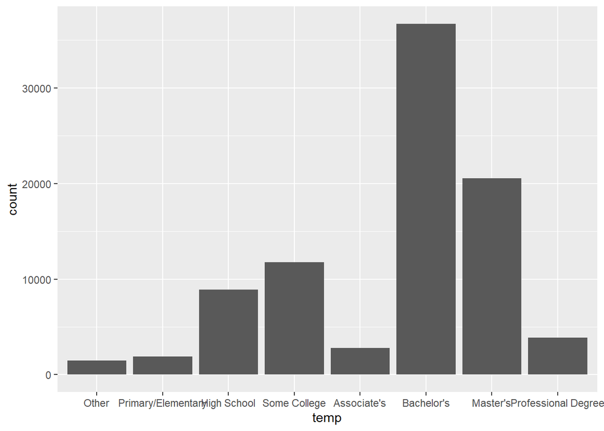

```r
ggplot(survey %>%
         select(EdLevel2) %>%
         drop_na(),
       aes(x = EdLevel2)) +
  geom_bar() +
  labs(x= "temp")
```

Add in some levels to pretty things up.

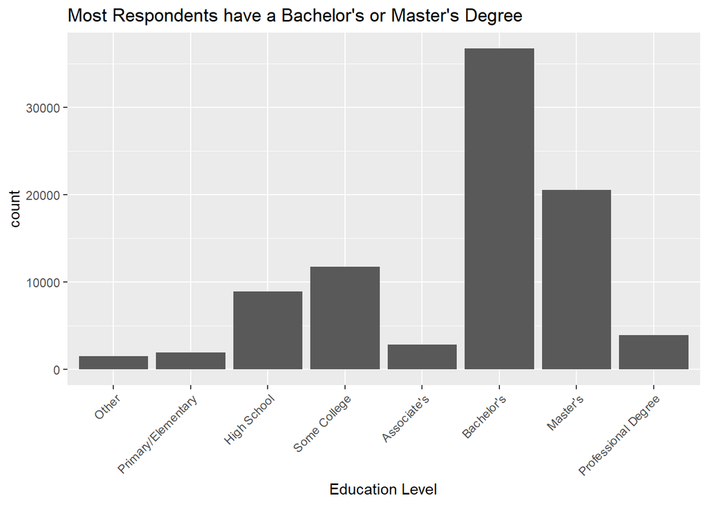

```r
ggplot(survey %>%
         select(EdLevel2) %>%
         drop_na(),
       aes(x = EdLevel2)) +
  geom_bar() +
  scale_x_discrete(guide = guide_axis(angle = 45)) +
  labs(x = "Education Level",
       title = "Most Respondents have a Bachelor's or Master's Degree")
```

We can involve a second variable by filling in the bars by another variable (here `AISentiment`).

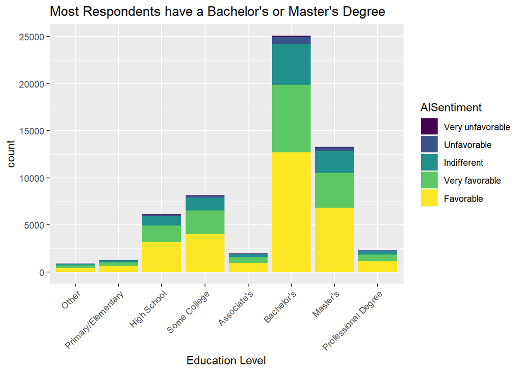

```r
ggplot(survey %>%
         select(EdLevel2, AISentiment) %>%
         filter(AISentiment != "Unsure") %>%
         drop_na(),
       aes(x = EdLevel2, fill = AISentiment)) +
  geom_bar() +
  scale_x_discrete(guide = guide_axis(angle = 45)) +
  labs(x = "Education Level",
       title = "Most Respondents have a Bachelor's or Master's Degree")
```

We can bring a third variable in by faceting the plot. This creates the same plot at each value of the faceting variable. This can be done with `facet_wrap()`. We’ll consider the `SOAccount` variable which has three values it takes on. That means we’ll get three plots out!

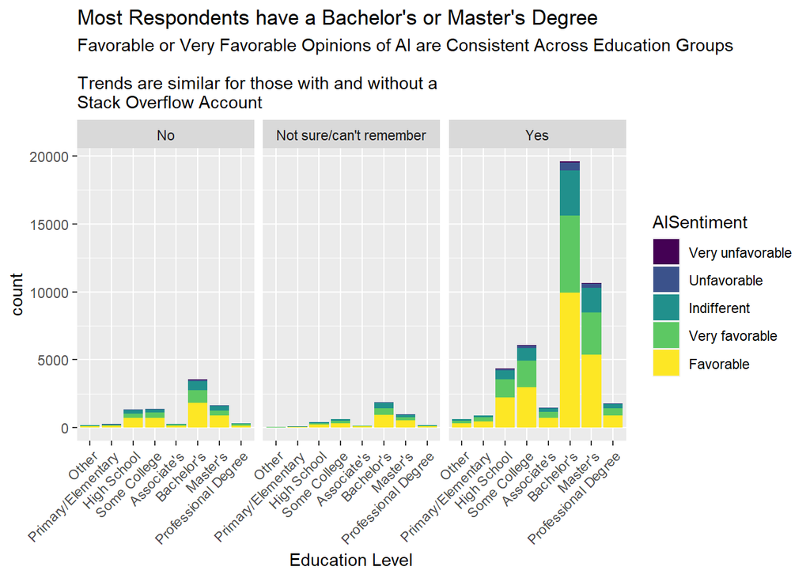

```r
ggplot(survey %>%
         select(EdLevel2, AISentiment, SOAccount) %>%
         filter(AISentiment != "Unsure") %>%
         drop_na(),
       aes(x = EdLevel2, fill = AISentiment)) +
  geom_bar() +
  facet_wrap(~SOAccount) +
  scale_x_discrete(guide = guide_axis(angle = 45)) +
  labs(x = "Education Level",
       title = "Most Respondents have a Bachelor's or Master's Degree",
       subtitle = "Favorable or Very Favorable Opinions of AI are Consistent Across Education Groups\n
Trends are similar for those with and without a
Stack Overflow Account")
```